# Pemodelan ARIMA - Data Kelompok

Uma Keisha Abriana

2026-09-30

## Packages

```r
library(ggplot2)
library(tsibble)
library(tseries)
library(MASS)
library(forecast)
library(TSA)
library(TTR)
library(aTSA)
library(graphics)
library(readxl)
```

## Data Real

Digunakan data CPIAUCSL_PC1 (perubahan persentase CPI dibanding tahun sebelumnya, bulanan) yang dalam hal ini hanya digunakan data 100 periode awal (Januari 1948 - April 1956).

```r
datacpi <- read_excel("D:\\SEM 5\\MPDW\\CPIAUCSL_PC1.xlsx", sheet = "Monthly")
# Hanya kolom 1-2 (tanggal & nilai), lalu ambil 100 data pertama
datacpi <- as.data.frame(datacpi[, 1:2])
colnames(datacpi) <- c("tanggal", "cpi")
datacpi <- datacpi[1:100,]
datacpi.ts <- ts(datacpi$cpi)

datacpi
```

```
##        tanggal      cpi
## 1   1948-01-01 10.24209
## 2   1948-02-01  9.48196
## 3   1948-03-01  6.81818
## 4   1948-04-01  8.27273
## 5   1948-05-01  9.38497
## 6   1948-06-01  9.37500
## 7   1948-07-01  9.76158
## 8   1948-08-01  9.06250
## 9   1948-09-01  6.65499
## 10  1948-10-01  6.11087
## 11  1948-11-01  4.77016
## 12  1948-12-01  2.73387
## 13  1949-01-01  1.39358
## 14  1949-02-01  1.01394
```

[output cut: 86 more lines]

### Eksplorasi Data

#### Plot Data Penuh

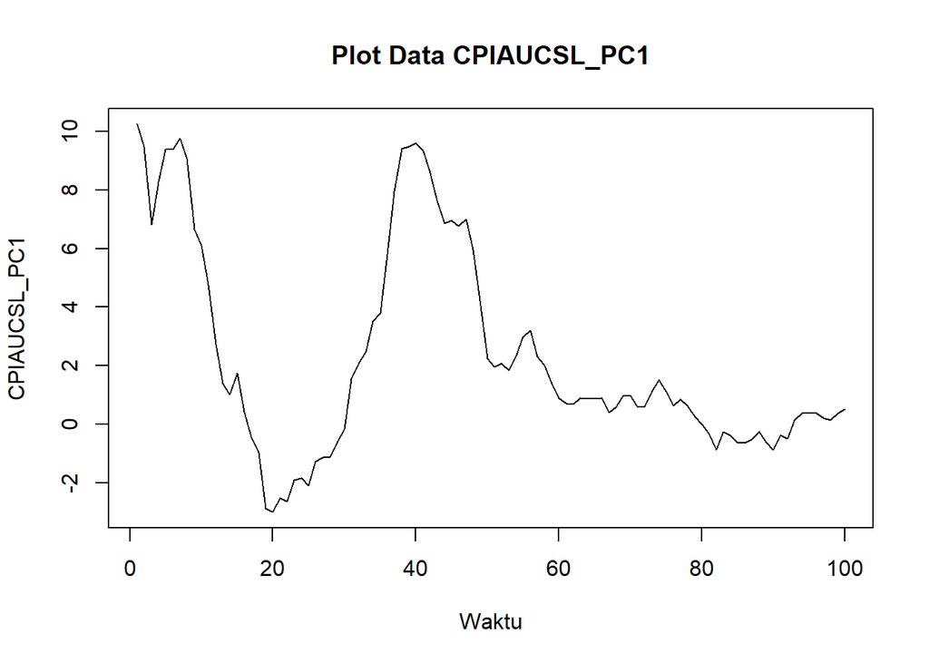

```r
plot.ts(datacpi.ts,
        lty = 1,
        xlab = "Waktu",
        ylab = "CPIAUCSL_PC1",
        main = "Plot Data CPIAUCSL_PC1")
```

Berdasarkan plot data deret waktu, terlihat bahwa data tidak bergerak di sekitar satu nilai tengah tertentu, melainkan naik-turun dengan pola yang panjang (tren / siklus). Pembagian data latih dan data uji ditetapkan dengan proporsi 80%:20%, yaitu 80 data latih dan 20 data uji.

#### Plot Data Latih

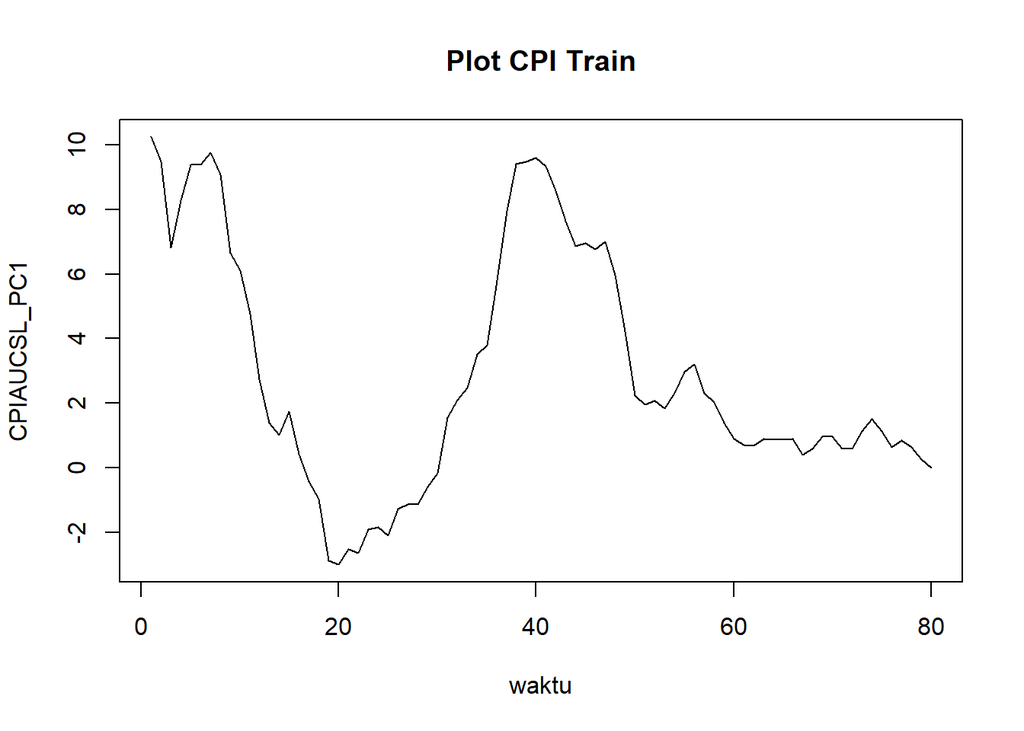

```r
cpitrain <- datacpi$cpi[1:80]
train.ts <- ts(cpitrain)
plot.ts(train.ts, lty=1, xlab="waktu", ylab="CPIAUCSL_PC1", main="Plot CPI Train")
```

Berdasarkan plot data deret waktu pada data latih, terlihat bahwa data cenderung tidak bergerak pada nilai tengah tertentu. Hal ini mengindikasikan bahwa data tidak stasioner dalam rataan.

#### Plot Data Uji

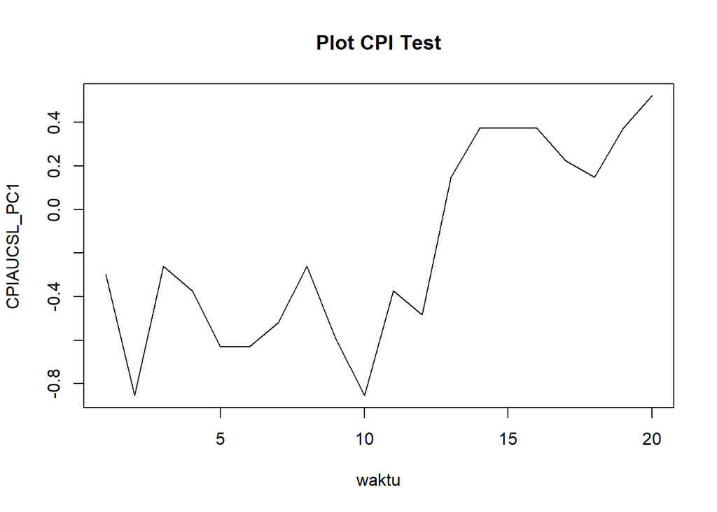

```r
cpitest <- datacpi$cpi[81:100]
test.ts <- ts(cpitest)
plot.ts(test.ts, lty=1, xlab="waktu", ylab="CPIAUCSL_PC1", main="Plot CPI Test")
```

### Uji Stasioneritas Data

#### Plot ACF

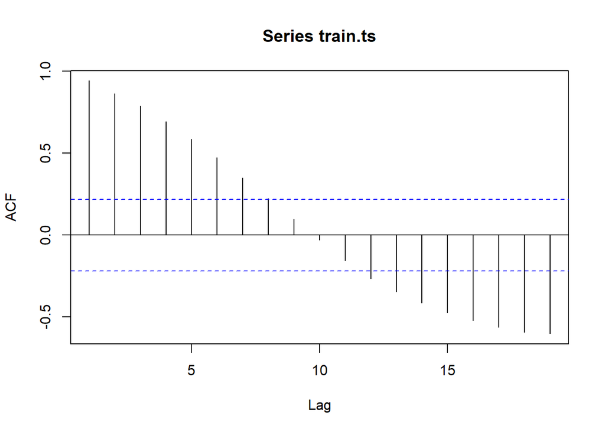

```r
acf(train.ts)
```

Berdasarkan plot ACF, terlihat bahwa plot ACF data menurun secara perlahan (*tails of slowly*). Hal ini menjadi indikasi bahwa data tidak stasioner dalam rataan.

#### Uji ADF

```r
tseries::adf.test(train.ts)
```

```
##
##  Augmented Dickey-Fuller Test
##
## data:  train.ts
## Dickey-Fuller = -2.5045, Lag order = 4, p-value = 0.3693
## alternative hypothesis: stationary
```

$H_0$ : Data tidak stasioner dalam rataan

$H_1$ : Data stasioner dalam rataan

Berdasarkan uji ADF tersebut, didapat *p-value* sebesar 0.3693 yang lebih besar dari taraf nyata 5% sehingga tak tolak $H_0$ dan menandakan bahwa data tidak stasioner dalam rataan. Hal ini sesuai dengan hasil eksplorasi menggunakan plot time series dan plot ACF, sehingga ketidakstasioneran data harus ditangani.

#### Plot Box-Cox

Data CPIAUCSL_PC1 memiliki nilai negatif, sedangkan Box-Cox hanya berlaku untuk data positif. Oleh karena itu, data digeser (ditambah konstanta) terlebih dahulu agar seluruh nilainya positif.

```r
index <- seq(1:80)

# Geser data agar > 0
min_val <- min(train.ts)
if (min_val <= 0) {
  c <- abs(min_val) + 1
  train.shifted <- train.ts + c
} else {
  train.shifted <- train.ts
}

# Box-Cox
bc <- boxcox(train.shifted ~ index, lambda = seq(-2, 2, by = 0.1))
```

[figure not shown]

```r
# Nilai lambda optimum (rounded)
lambda_opt <- bc$x[which.max(bc$y)]
lambda_opt
```

```
## [1] 0.5050505
```

```r
# Selang kepercayaan 95% untuk lambda
ci_lambda <- bc$x[bc$y > max(bc$y) - 0.5 * qchisq(0.95, df = 1)]

# Batas bawah dan batas atas
ci_lower <- min(ci_lambda)
ci_upper <- max(ci_lambda)

c(Batas_Bawah = ci_lower, Batas_Atas = ci_upper)
```

```
## Batas_Bawah  Batas_Atas
##   0.1818182   0.8282828
```

Nilai $\lambda$ optimum sebesar 0.505 dengan selang kepercayaan 95% berkisar 0.18 sampai 0.83. Selang tersebut tidak memuat nilai satu sehingga data latih belum stasioner dalam ragam. Namun, pada praktikum ini penanganan difokuskan pada kestasioneran dalam rataan melalui differencing, kemudian kestasioneran ragam dicek kembali pada data hasil differencing.

### Penanganan Ketidakstasioneran Data

#### Differencing Pertama

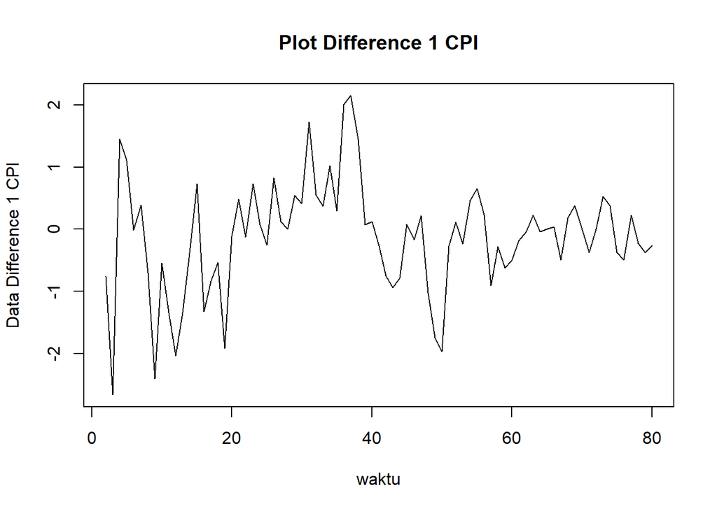

```r
# Differencing pertama
train.diff1 <- diff(train.ts, differences = 1)

# Plot hasil differencing
plot.ts(train.diff1, lty=1, xlab="waktu", ylab="Data Difference 1 CPI", main="Plot Difference 1 CPI")
```

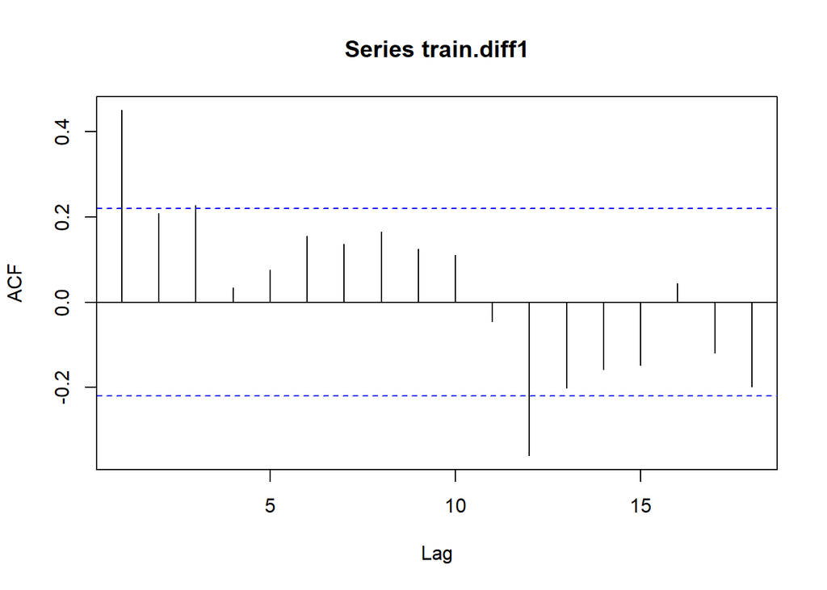

```r
acf(train.diff1)
```

```r
tseries::adf.test(train.diff1)
```

```
##
##  Augmented Dickey-Fuller Test
##
## data:  train.diff1
## Dickey-Fuller = -2.7913, Lag order = 4, p-value = 0.2521
## alternative hypothesis: stationary
```

$H_0$ : Data tidak stasioner dalam rataan

$H_1$ : Data stasioner dalam rataan

Berdasarkan uji ADF tersebut, didapat *p-value* sebesar 0.2521 yang lebih besar dari taraf nyata 5% sehingga tak tolak $H_0$ dan menandakan bahwa data hasil differencing pertama **masih belum stasioner** dalam rataan. Oleh karena itu, dilakukan differencing kedua.

#### Differencing Kedua

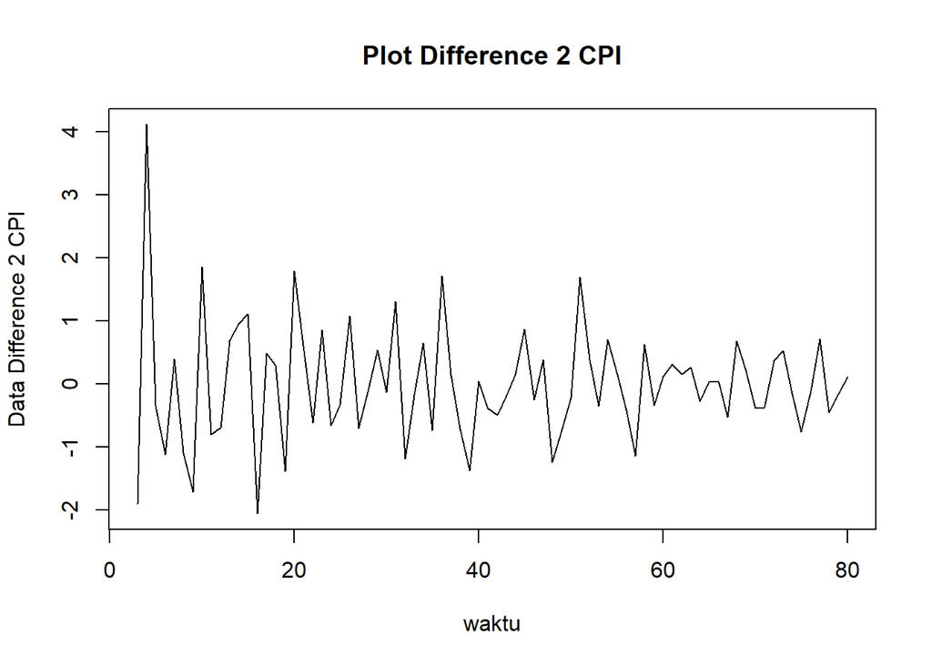

```r
# Differencing kedua
train.diff <- diff(train.ts, differences = 2)

# Plot hasil differencing
plot.ts(train.diff, lty=1, xlab="waktu", ylab="Data Difference 2 CPI", main="Plot Difference 2 CPI")
```

Berdasarkan plot data deret waktu, terlihat bahwa data hasil differencing kedua bergerak di sekitar nilai tengah nol (tidak terdapat tren pada data).

#### Plot ACF

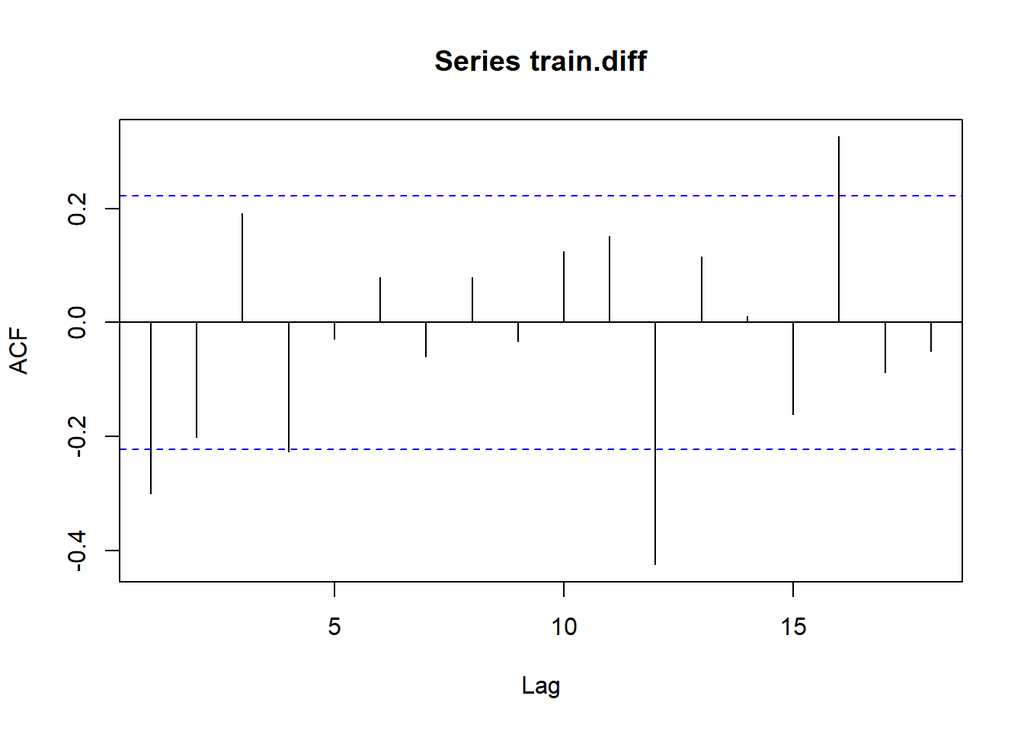

```r
acf(train.diff)
```

#### Uji ADF

```r
tseries::adf.test(train.diff)
```

```
##
##  Augmented Dickey-Fuller Test
##
## data:  train.diff
## Dickey-Fuller = -5.8932, Lag order = 4, p-value = 0.01
## alternative hypothesis: stationary
```

$H_0$ : Data tidak stasioner dalam rataan

$H_1$ : Data stasioner dalam rataan

Jika *p-value* < 0.05 (pada perhitungan awal statistik uji ADF sekitar -5.89 sehingga *p-value* dilaporkan 0.01) maka tolak $H_0$ dan data hasil differencing kedua stasioner dalam rataan sehingga dapat dilanjutkan ke pemodelan dengan $d = 2$.

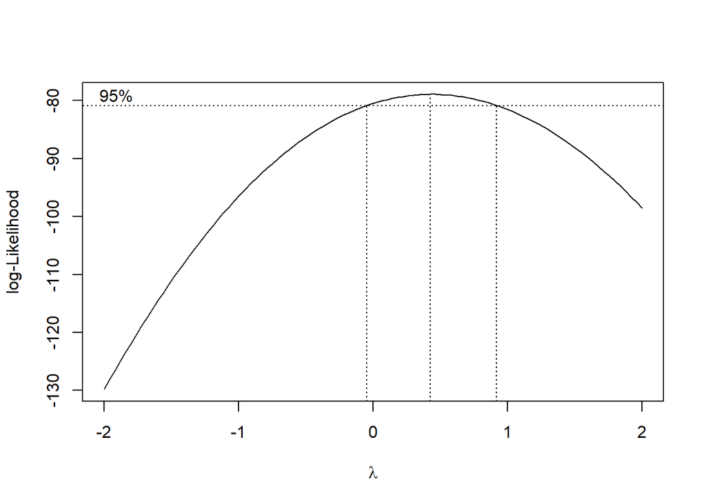

```r
library(MASS)

# 1. Sesuaikan panjang index karena differencing menghilangkan observasi awal
index_diff <- seq(1:length(train.diff))

# 2. Cek apakah ada nilai negatif/nol. Jika ada, tambahkan konstanta (c)
# agar nilai minimum data menjadi > 0 (misalnya menjadi 1)
min_val <- min(train.diff)

if (min_val <= 0) {
  c <- abs(min_val) + 1
  train.diff_shifted <- train.diff + c
} else {
  train.diff_shifted <- train.diff
}

# 3. Plot Box-Cox pada data yang sudah di-shift
bc_diff <- boxcox(train.diff_shifted ~ index_diff, lambda = seq(-2, 2, by = 0.1))
```

```r
# 4. Nilai lambda optimum (rounded)
lambda_opt_diff <- bc_diff$x[which.max(bc_diff$y)]
print(paste("Lambda optimum setelah diff:", lambda_opt_diff))
```

```
## [1] "Lambda optimum setelah diff: 0.424242424242424"
```

```r
# 5. Selang kepercayaan 95% untuk lambda
ci_lambda_diff <- bc_diff$x[bc_diff$y > max(bc_diff$y) - 0.5 * qchisq(0.95, df = 1)]

# Batas bawah dan batas atas
ci_lower_diff <- min(ci_lambda_diff)
ci_upper_diff <- max(ci_lambda_diff)

c(Batas_Bawah = ci_lower_diff, Batas_Atas = ci_upper_diff)
```

```
## Batas_Bawah  Batas_Atas
## -0.02020202  0.90909091
```

### Identifikasi Model

#### Plot ACF

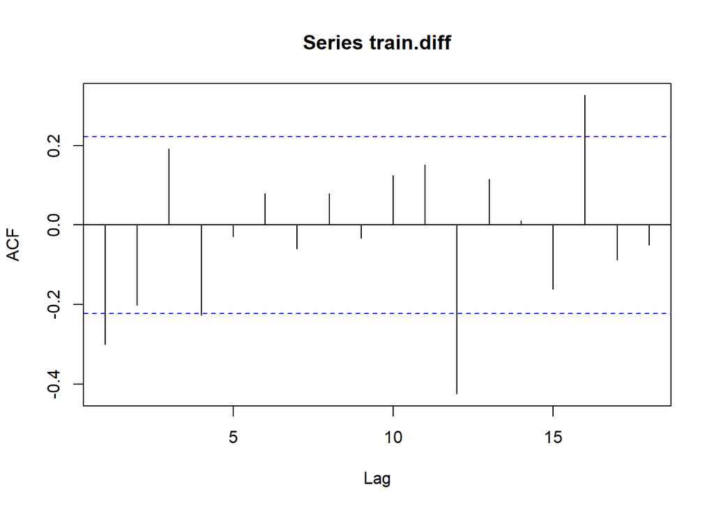

```r
acf(train.diff)
```

Pada perhitungan awal, ACF data differencing kedua signifikan pada lag ke-1 (bernilai negatif sekitar -0.30) dan lag-lag berikutnya berada di sekitar batas signifikansi. Perhatikan lag mana saja yang keluar dari batas pada plot Anda.

#### Plot PACF

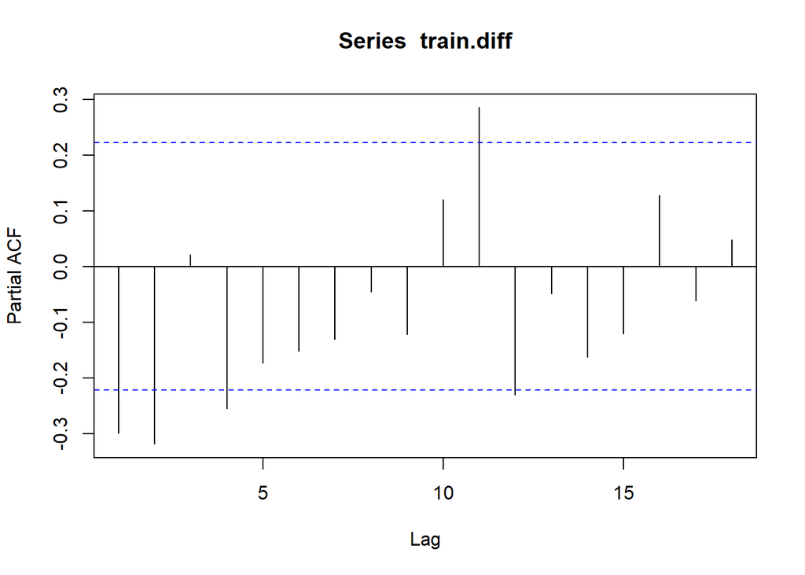

```r
pacf(train.diff)
```

#### Plot EACF

```r
eacf(train.diff)
```

```
## AR/MA
##   0 1 2 3 4 5 6 7 8 9 10 11 12 13
## 0 x o o o o o o o o o o  x  o  o
## 1 x x o o o o o o o o o  x  o  o
## 2 o x o x o o o o o o o  x  o  o
## 3 o x x o o o o o o o o  x  o  o
## 4 x o o o o o o o o o o  o  o  o
## 5 x x o o o o o o o o o  o  o  o
## 6 x x o o o o o o o o o  o  o  o
## 7 x x o o o o o o o o o  o  o  o
```

### Pendugaan Parameter Model Tentatif

#### ARIMA(0,2,1)

```r
model1.da=Arima(train.diff, order=c(0,0,1),method="ML")
summary(model1.da)
```

```
## Series: train.diff
## ARIMA(0,0,1) with non-zero mean
##
## Coefficients:
##           ma1    mean
##       -0.6466  0.0055
## s.e.   0.1370  0.0348
##
## sigma^2 = 0.7385:  log likelihood = -98.11
## AIC=202.22   AICc=202.55   BIC=209.29
##
## Training set error measures:
##                       ME      RMSE       MAE      MPE     MAPE      MASE
## Training set 0.009015606 0.8482678 0.6381856 69.71705 149.0148 0.5808749
##                  ACF1
## Training set 0.161611
```

```r
lmtest::coeftest(model1.da)
```

```
##
## z test of coefficients:
##
##             Estimate Std. Error z value  Pr(>|z|)
## ma1       -0.6465587  0.1370438 -4.7179 2.383e-06 ***
## intercept  0.0055348  0.0347923  0.1591    0.8736
## ---
## Signif. codes:  0 '***' 0.001 '**' 0.01 '*' 0.05 '.' 0.1 ' ' 1
```

#### ARIMA(2,2,0)

```r
model2.da=Arima(train.diff, order=c(2,0,0),method="ML")
summary(model2.da)
```

```
## Series: train.diff
## ARIMA(2,0,0) with non-zero mean
##
## Coefficients:
##           ar1      ar2    mean
##       -0.3875  -0.3767  0.0056
## s.e.   0.1068   0.1217  0.0546
##
## sigma^2 = 0.7387:  log likelihood = -97.53
## AIC=203.06   AICc=203.61   BIC=212.49
##
## Training set error measures:
##                       ME      RMSE      MAE      MPE     MAPE      MASE
## Training set 0.003095861 0.8427847 0.617926 56.81787 122.2417 0.5624347
##                    ACF1
## Training set 0.01271517
```

```r
lmtest::coeftest(model2.da)
```

```
##
## z test of coefficients:
##
##             Estimate Std. Error z value  Pr(>|z|)
## ar1       -0.3874950  0.1067784 -3.6290 0.0002846 ***
## ar2       -0.3767093  0.1217335 -3.0945 0.0019712 **
## intercept  0.0055643  0.0545857  0.1019 0.9188069
## ---
## Signif. codes:  0 '***' 0.001 '**' 0.01 '*' 0.05 '.' 0.1 ' ' 1
```

#### ARIMA(1,2,1)

```r
model3.da=Arima(train.diff, order=c(1,0,1),method="ML")
summary(model3.da)
```

```
## Series: train.diff
## ARIMA(1,0,1) with non-zero mean
##
## Coefficients:
##          ar1      ma1    mean
##       0.4589  -1.0000  0.0044
## s.e.  0.1023   0.0498  0.0071
##
## sigma^2 = 0.6654:  log likelihood = -94.96
## AIC=197.91   AICc=198.46   BIC=207.34
##
## Training set error measures:
##                      ME      RMSE       MAE      MPE     MAPE     MASE
## Training set 0.04383905 0.7998548 0.5776209 76.02905 108.8686 0.525749
##                     ACF1
## Training set -0.02336469
```

```r
lmtest::coeftest(model3.da)
```

```
##
## z test of coefficients:
##
##             Estimate Std. Error  z value  Pr(>|z|)
## ar1        0.4589075  0.1023293   4.4846 7.305e-06 ***
## ma1       -0.9999996  0.0498061 -20.0778 < 2.2e-16 ***
## intercept  0.0044449  0.0070668   0.6290    0.5294
## ---
## Signif. codes:  0 '***' 0.001 '**' 0.01 '*' 0.05 '.' 0.1 ' ' 1
```

#### ARIMA(0,2,2)

```r
model4.da=Arima(train.diff, order=c(0,0,2),method="ML")
summary(model4.da)
```

```
## Series: train.diff
## ARIMA(0,0,2) with non-zero mean
##
## Coefficients:
##           ma1      ma2    mean
##       -0.4396  -0.3770  0.0050
## s.e.   0.1356   0.1779  0.0185
##
## sigma^2 = 0.6872:  log likelihood = -95.02
## AIC=198.03   AICc=198.58   BIC=207.46
##
## Training set error measures:
##                       ME      RMSE       MAE      MPE     MAPE      MASE
## Training set 0.003103169 0.8128903 0.5934649 74.44941 119.8831 0.5401703
##                    ACF1
## Training set -0.0468983
```

```r
lmtest::coeftest(model4.da)
```

```
##
## z test of coefficients:
##
##             Estimate Std. Error z value Pr(>|z|)
## ma1       -0.4396293  0.1355514 -3.2433 0.001182 **
## ma2       -0.3770443  0.1779385 -2.1190 0.034094 *
## intercept  0.0050293  0.0185082  0.2717 0.785826
## ---
## Signif. codes:  0 '***' 0.001 '**' 0.01 '*' 0.05 '.' 0.1 ' ' 1
```

#### ARIMA(1,2,2)

```r
model5.da=Arima(train.diff, order=c(1,0,2),method="ML")
summary(model5.da)
```

```
## Series: train.diff
## ARIMA(1,0,2) with non-zero mean
##
## Coefficients:
##           ar1     ma1      ma2    mean
##       -0.5661  0.1709  -0.7471  0.0030
## s.e.   0.1288  0.1129   0.0985  0.0253
##
## sigma^2 = 0.6498:  log likelihood = -92.72
## AIC=195.44   AICc=196.27   BIC=207.22
##
## Training set error measures:
##                       ME      RMSE       MAE     MPE     MAPE      MASE
## Training set 0.009457452 0.7851785 0.5717526 63.6325 119.5945 0.5204077
##                      ACF1
## Training set -0.004212131
```

```r
lmtest::coeftest(model5.da)
```

```
##
## z test of coefficients:
##
##            Estimate Std. Error z value  Pr(>|z|)
## ar1       -0.566112   0.128827 -4.3943 1.111e-05 ***
## ma1        0.170892   0.112880  1.5139    0.1300
## ma2       -0.747084   0.098474 -7.5866 3.284e-14 ***
## intercept  0.003048   0.025254  0.1207    0.9039
## ---
## Signif. codes:  0 '***' 0.001 '**' 0.01 '*' 0.05 '.' 0.1 ' ' 1
```

### Ringkasan AIC

```r
model_tentatif <- data.frame(
  Model = c("ARIMA(0,2,1)","ARIMA(2,2,0)","ARIMA(1,2,1)", "ARIMA(0,2,2)",
            "ARIMA(1,2,2)"),
  AIC   = c(AIC(model1.da),AIC(model2.da), AIC(model3.da), AIC(model4.da), AIC(model5.da)),
  BIC   = c(BIC(model1.da),BIC(model2.da), BIC(model3.da), BIC(model4.da), BIC(model5.da))
)

model_tentatif
```

```
##          Model      AIC      BIC
## 1 ARIMA(0,2,1) 202.2246 209.2947
## 2 ARIMA(2,2,0) 203.0602 212.4871
## 3 ARIMA(1,2,1) 197.9145 207.3413
## 4 ARIMA(0,2,2) 198.0335 207.4603
## 5 ARIMA(1,2,2) 195.4365 207.2201
```

Model terbaik dipilih berdasarkan nilai AIC terkecil **dan** parameter model yang signifikan (cek `coeftest` di atas). Pilih satu model, lalu tetapkan pada chunk berikut. Secara default, kode memilih model dengan AIC terkecil; jika model tersebut memiliki parameter yang tidak signifikan, ganti dengan model lain yang lebih layak.

```r
daftar_model <- list(model1.da, model2.da, model3.da, model4.da, model5.da)
idx_terbaik  <- which.min(model_tentatif$AIC)
model_terbaik <- daftar_model[[idx_terbaik]]
model_tentatif$Model[idx_terbaik]
```

```
## [1] "ARIMA(1,2,2)"
```

### Analisis Sisaan

Model terbaik hasil identifikasi kemudian dicek asumsi sisaannya. Sisaan model ARIMA harus memenuhi asumsi normalitas, kebebasan sisaan, dan kehomogenan ragam. Diagnostik model dilakukan secara eksplorasi dan uji formal.

#### Eksplorasi Sisaan

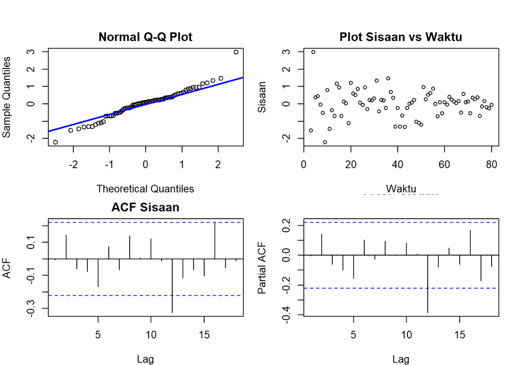

```r
sisaan.da <- model_terbaik$residuals

par(mfrow = c(2,2),
    mar = c(4,4,2,1),
    oma = c(0,0,2,0))

# Q-Q Plot
qqnorm(sisaan.da, main = "Normal Q-Q Plot")
qqline(sisaan.da, col = "blue", lwd = 2)

# Plot Sisaan vs Waktu
plot(sisaan.da, type = "p",
     main = "Plot Sisaan vs Waktu",
     xlab = "Waktu", ylab = "Sisaan")

# ACF
acf(sisaan.da, main = "ACF Sisaan")

# PACF
pacf(sisaan.da, main = "PACF Sisaan")
```

```r
par(mfrow = c(1,1))
```

Amati plot kuantil-kuantil normal (apakah titik mengikuti garis $45^{\circ}$), plot sisaan terhadap waktu (apakah lebar pita relatif sama), serta plot ACF dan PACF sisaan (apakah ada *spike* signifikan). Kondisi ini diuji lebih lanjut dengan uji formal.

#### Uji Formal

```r
#1) Sisaan Menyebar Normal
ks.test(sisaan.da,"pnorm")
```

```
##
##  Exact one-sample Kolmogorov-Smirnov test
##
## data:  sisaan.da
## D = 0.11555, p-value = 0.2302
## alternative hypothesis: two-sided
```

$H_0$ : Sisaan menyebar normal

$H_1$ : Sisaan tidak menyebar normal

Jika *p-value* > 0.05 maka gagal tolak $H_0$ (sisaan menyebar normal).

```r
#2) Sisaan saling bebas/tidak ada autokorelasi
Box.test(sisaan.da, type = "Ljung")
```

```
##
##  Box-Ljung test
##
## data:  sisaan.da
## X-squared = 0.0014378, df = 1, p-value = 0.9698
```

$H_0$ : Sisaan saling bebas

$H_1$ : Sisaan tidak saling bebas

Jika *p-value* > 0.05 maka gagal tolak $H_0$ (sisaan saling bebas).

```r
#3) Sisaan homogen
Box.test((sisaan.da)^2, type = "Ljung")
```

```
##
##  Box-Ljung test
##
## data:  (sisaan.da)^2
## X-squared = 1.0878, df = 1, p-value = 0.297
```

$H_0$ : Ragam sisaan homogen

$H_1$ : Ragam sisaan tidak homogen

Jika *p-value* > 0.05 maka gagal tolak $H_0$ (ragam sisaan homogen).

```r
#4) Nilai tengah sisaan sama dengan nol
t.test(sisaan.da, mu = 0, conf.level = 0.95)
```

```
##
##  One Sample t-test
##
## data:  sisaan.da
## t = 0.1057, df = 77, p-value = 0.9161
## alternative hypothesis: true mean is not equal to 0
## 95 percent confidence interval:
##  -0.1687059  0.1876208
## sample estimates:
##   mean of x
## 0.009457452
```

$H_0$ : nilai tengah sisaan sama dengan 0

$H_1$ : nilai tengah sisaan tidak sama dengan 0

Jika *p-value* > 0.05 maka gagal tolak $H_0$ (nilai tengah sisaan sama dengan nol).

### Overfitting

```r
model6.da=Arima(train.diff, order=c(0,0,3),method="ML")
summary(model6.da)
```

```
## Series: train.diff
## ARIMA(0,0,3) with non-zero mean
##
## Coefficients:
##           ma1      ma2     ma3    mean
##       -0.4016  -0.4942  0.1586  0.0028
## s.e.   0.1223   0.1761  0.1502  0.0254
##
## sigma^2 = 0.6868:  log likelihood = -94.44
## AIC=198.88   AICc=199.72   BIC=210.67
##
## Training set error measures:
##                      ME      RMSE      MAE      MPE     MAPE      MASE
## Training set 0.00664342 0.8071896 0.605648 68.15652 125.9739 0.5512592
##                     ACF1
## Training set -0.04772337
```

```r
lmtest::coeftest(model6.da)
```

```
##
## z test of coefficients:
##
##             Estimate Std. Error z value Pr(>|z|)
## ma1       -0.4016340  0.1223267 -3.2833 0.001026 **
## ma2       -0.4942128  0.1761337 -2.8059 0.005018 **
## ma3        0.1586080  0.1501916  1.0560 0.290951
## intercept  0.0027964  0.0253566  0.1103 0.912186
## ---
## Signif. codes:  0 '***' 0.001 '**' 0.01 '*' 0.05 '.' 0.1 ' ' 1
```

```r
overfitting <- data.frame(
  Model = c("ARIMA(0,2,2)", "ARIMA(1,2,2)", "ARIMA(0,2,3)"),
  AIC   = c(AIC(model4.da), AIC(model5.da), AIC(model6.da)),
  BIC   = c(BIC(model4.da), BIC(model5.da), BIC(model6.da))
)

overfitting
```

```
##          Model      AIC      BIC
## 1 ARIMA(0,2,2) 198.0335 207.4603
## 2 ARIMA(1,2,2) 195.4365 207.2201
## 3 ARIMA(0,2,3) 198.8849 210.6685
```

Jika model hasil *overfitting* tidak memiliki AIC yang lebih kecil dan parameternya tidak seluruhnya signifikan, maka model awal tetap digunakan untuk peramalan.

### Model Terbaik

Model terbaik yang digunakan untuk peramalan adalah `model_terbaik` hasil pemilihan di atas (atau model hasil *overfitting* jika lebih baik).

```r
summary(model_terbaik)
```

```
## Series: train.diff
## ARIMA(1,0,2) with non-zero mean
##
## Coefficients:
##           ar1     ma1      ma2    mean
##       -0.5661  0.1709  -0.7471  0.0030
## s.e.   0.1288  0.1129   0.0985  0.0253
##
## sigma^2 = 0.6498:  log likelihood = -92.72
## AIC=195.44   AICc=196.27   BIC=207.22
##
## Training set error measures:
##                       ME      RMSE       MAE     MPE     MAPE      MASE
## Training set 0.009457452 0.7851785 0.5717526 63.6325 119.5945 0.5204077
##                      ACF1
## Training set -0.004212131
```

```r
lmtest::coeftest(model_terbaik)
```

```
##
## z test of coefficients:
##
##            Estimate Std. Error z value  Pr(>|z|)
## ar1       -0.566112   0.128827 -4.3943 1.111e-05 ***
## ma1        0.170892   0.112880  1.5139    0.1300
## ma2       -0.747084   0.098474 -7.5866 3.284e-14 ***
## intercept  0.003048   0.025254  0.1207    0.9039
## ---
## Signif. codes:  0 '***' 0.001 '**' 0.01 '*' 0.05 '.' 0.1 ' ' 1
```

### Peramalan

Peramalan dilakukan menggunakan fungsi `forecast()`. Peramalan berikut ini dilakukan untuk 20 periode ke depan (sepanjang data uji).

```r
# ---FORECAST---
ramalan.da <- forecast::forecast(model_terbaik, h = length(test.ts))
ramalan.da
```

```
##     Point Forecast      Lo 80    Hi 80     Lo 95    Hi 95
##  81    0.128663802 -0.9044405 1.161768 -1.451333 1.708661
##  82   -0.014173913 -1.1250489 1.096701 -1.713111 1.684763
##  83    0.012797604 -1.2226401 1.248235 -1.876641 1.902237
##  84   -0.002471306 -1.2752524 1.270310 -1.949022 1.944079
##  85    0.006172613 -1.2783467 1.290692 -1.958330 1.970675
##  86    0.001279184 -1.2869794 1.289538 -1.968942 1.971501
##  87    0.004049415 -1.2854053 1.293504 -1.968001 1.976100
##  88    0.002481153 -1.2873566 1.292319 -1.970155 1.975118
##  89    0.003368965 -1.2865915 1.293329 -1.969455 1.976193
##  90    0.002866364 -1.2871335 1.292866 -1.970018 1.975751
##  91    0.003150893 -1.2868616 1.293163 -1.969753 1.976055
##  92    0.002989817 -1.2870267 1.293006 -1.969920 1.975900
##  93    0.003081004 -1.2869368 1.293099 -1.969831 1.975993
##  94    0.003029382 -1.2869888 1.293048 -1.969883 1.975942
##  95    0.003058606 -1.2869597 1.293077 -1.969854 1.975971
##  96    0.003042062 -1.2869763 1.293060 -1.969871 1.975955
##  97    0.003051428 -1.2869670 1.293070 -1.969861 1.975964
##  98    0.003046126 -1.2869723 1.293065 -1.969867 1.975959
##  99    0.003049127 -1.2869693 1.293068 -1.969864 1.975962
## 100    0.003047428 -1.2869710 1.293066 -1.969865 1.975960
```

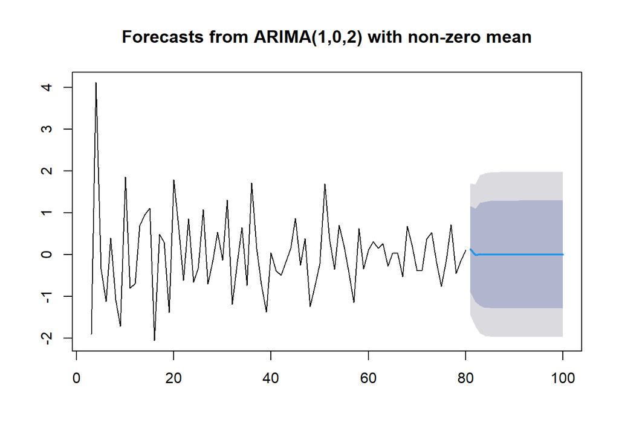

```r
data.ramalan.da <- ramalan.da$mean
plot(ramalan.da)
```

Hasil ramalan di atas adalah ramalan untuk data differencing kedua, sehingga perlu dikembalikan ke skala data asli dengan *inverse differencing* sebanyak dua kali. Karena $d = 2$, dibutuhkan **dua nilai terakhir** data latih sebagai nilai awal (`xi`), dan **dua nilai pertama** hasil `diffinv` dibuang.

```r
# Inverse differencing (d = 2)
pt_akhir_train <- tail(train.ts, 2)

forecast <- diffinv(data.ramalan.da, differences = 2, xi = pt_akhir_train)
hasil <- forecast[-c(1:2)]

# Bandingkan aktual vs forecast
perbandingan.da <- cbind(
  Aktual   = test.ts,
  Forecast = hasil
)

print(head(perbandingan.da, 10))
```

```
## Time Series:
## Start = 1
## End = 10
## Frequency = 1
##      Aktual   Forecast
##  1 -0.29751 -0.1326262
##  2 -0.85343 -0.2794263
##  3 -0.26071 -0.4134288
##  4 -0.37216 -0.5499026
##  5 -0.63103 -0.6802038
##  6 -0.62986 -0.8092258
##  7 -0.51987 -0.9341984
##  8 -0.26061 -1.0566899
##  9 -0.59413 -1.1758124
## 10 -0.85375 -1.2920685
```

```r
# Hitung akurasi
akurasi_test <- accuracy(hasil, test.ts)
akurasi_test
```

```
##                ME     RMSE      MAE      MPE    MAPE      ACF1 Theil's U
## Test set 1.118696 1.520739 1.192585 282.6474 399.389 0.8424515  7.595839
```

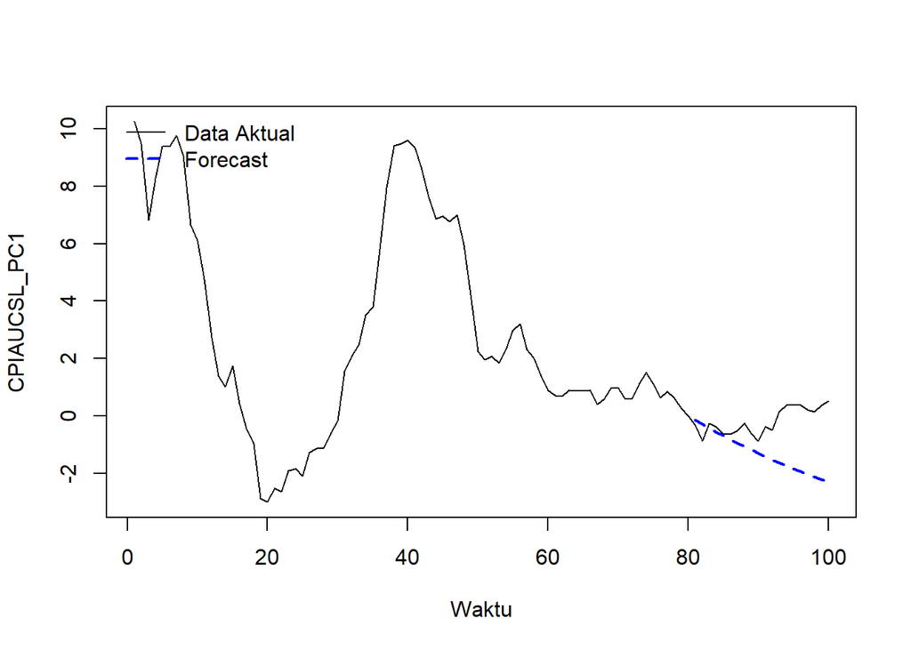

```r
# Plot data
ts.plot(datacpi.ts, col = "black", lty = 1,
        xlab = "Waktu", ylab = "CPIAUCSL_PC1")

# Garis forecast
lines(81:(80+length(hasil)), hasil, col = "blue", lty = 2, lwd = 2)
legend("topleft",
       legend = c("Data Aktual", "Forecast"),
       col = c("black", "blue"),
       lty = c(1,2), lwd = c(1,2), bty = "n")
```